# jekyll-jupyter-notebook20260929-3337-7ur0av

## How to work on this?

https://tinyurl.com/pythhonn

Copy and Work

Source of Problems: GFG, Think Python

## 1. Variables, Keywords, and Identifiers

**Variables**: Hold data during program execution.

**Identifiers**: Names for variables, functions, etc.

**Keywords**: Reserved words (e.g., if, for) – cannot be used as variable names.

**Rules**:

1. No starting with numbers
2. No spaces → use `_`
3. Avoid special symbols: :`"<>/\|()!@&%...`

```python
student_name = "Anna"
student_age = 20
print(student_name, student_age)

import keyword
print(keyword.iskeyword('for'))     # True
print(keyword.iskeyword('hello'))   # False

print(keyword.kwlist)
```

```
Anna 20
True
False
['False', 'None', 'True', 'and', 'as', 'assert', 'async', 'await', 'break', 'class', 'continue', 'def', 'del', 'elif', 'else', 'except', 'finally', 'for', 'from', 'global', 'if', 'import', 'in', 'is', 'lambda', 'nonlocal', 'not', 'or', 'pass', 'raise', 'return', 'try', 'while', 'with', 'yield']
```

Rule of Precedence => PEMDAS

```
result = 4 + 3 * 2 ** 2 - (6 / 3)
print(result)
```

```python
result = 4 + 3 * 2 ** 2 - (6 / 3)
print(result)
```

```
14.0
```

**Problem 1: Secret Agent Code Name Generator**

You're a spy. Create a code name using:

1. First letter of your first name
2. Last 3 letters of your city
3. Your age doubled

Example: Anna from Krakow, age 20 → A KOW 40 → AKOW40

Hint: .upper() => method and str() => function.

Think: Method vs Function?

```python
name = "Satyam"

city = "Krakow"

age = 23

code = name[0] + city[-3:] + str(age*2)

print(code) #So we are all kows?
```

```
Skow46
```

**Bonus Problem: Secret Agent Name Validator**

A spy agency only accepts valid Python variable names as code names.

Tasks: Take input: agent_name = input("Enter code name: ")

Check:

1. Starts with letter or _
2. No spaces
3. Not a Python keyword

Print: "ACCEPTED" or "REJECTED: Invalid name"

Hint: isalpha() method of the string & kwlist of keyword module

```python
name = input("Enter Code Name: ")

check_1 = name[0].isalpha() or name[0] == "_"
check_2 = " " not in name
check_3 = not keyword.iskeyword(name)

if check_1 and check_2 and check_3:
  print("ACCEPTED")
```

```
Enter Code Name: Skow23
ACCEPTED
```

## 2. Dynamic Typing: Feature or Flaw?

Python allows reassigning variables to any data type => Dynamic Typing

| Pros | Cons |
| --- | --- |
| Fast prototyping | Risk of type bugs |
| Flexible | Not allowed in C/Java |

```python
value = 100
print(type(value))  # <class 'int'>

value = "hundred"
print(type(value))  # <class 'str'>

value = [1, 2, 3]
print(type(value))  # <class 'list'>

#value+3 #This would give error
```

```
<class 'int'>
<class 'str'>
<class 'list'>
```

**Problem 2: Shape Shifter**

A magical creature changes form every second:

1. Start as dragon = 3 (3 heads)
2. Becomes dragon = "fire" (breathes fire)
3. Becomes dragon = [10, 20, 30] (gains 3 wings)

Print its type and identity at each stage.

Then, intentionally cause a bug by adding dragon + 5 — explain the error.

```python
dragon = 3
print(type(dragon), id(dragon))

dragon = "fire"
print(type(dragon), id(dragon))

dragon = [10,20,30]
print(type(dragon), id(dragon))

#dragon+5
```

```
<class 'int'> 11654440
<class 'str'> 136018637860432
<class 'list'> 136017696766016
```

**Bonus Problem: Time Traveler’s Log** [Home]

A time machine records data in different types each jump.

Tasks:

1. Start: log = 1364 → Year founded
2. Jump: log = "Jagiellonian" → University name
3. Jump: log = [50.0, 20.0] → Coordinates
4. Final: log = {"status": "stable"}
5. Print type and value at each jump

Then, intentionally cause a TypeError and explain.

## 3. Strings

- Enclosed in quotes: 'hello' or "hello"
- Immutable → cannot change individual characters
- Support indexing, slicing, concatenation

```python
uni = "Jagiellonian University"
print(len(uni))
print(uni[0])           # 'J'
print(uni[::2])         # every 2nd char
print(uni[-10:])        # last 10 chars
```

```
23
J
Jgelna nvriy
University
```

**Problem 3: Palindrome Detector**

Check if a word is a palindrome (reads same forward and backward). Steps:

1. Take input word: word = "radar"
2. Reverse it using slicing
3. Compare with original
4. Print "Yes!" or "No!"

Bonus: Try "Python" → should say "No!"

```python
word = "radar"
reversed_word = word[::-1]
if word == reversed_word:
  print("Yes!")
```

```
Yes!
```

**Bonus Problem: Input a character, and find the index of that character in some string. If not found, print None**

```python
string = "Hello"
character = "l"

# if character in string:
#   index = string.index(character)
#   print(index)

found = False
for i in range(len(string)):
  if string[i] == character:
    found = True
    print(i)

if not found:
  print("None")
```

```
2
3
```

## 4. Lists

- Mutable sequences: `[1, "a", 3.14]`
- Support indexing, slicing, append, +, *

```python
fruits = ["apple", "banana"]
fruits = fruits + ["mango"]
print(fruits * 2)
```

```
['apple', 'banana', 'mango', 'apple', 'banana', 'mango']
```

**Problem 4: Cumulative Sum**

Write a piece of code that takes a list of numbers and returns the cumulative sum; that is, a new list where the ith element is the sum of the first i + 1 elements from the original list.

For example, the cumulative sum of [1, 2, 3] is [1, 3, 6].

```python
lis = [1,2,3]

cumulative = []

for i in range(len(lis)):
  cumulative.append(sum(lis[:i+1]))

print(cumulative)
```

```
[1, 3, 6]
```

**Bonus Problem: Nested Sum**

Write a piece of code that takes a nested list of integers and add up the elements from all of the nested lists.

```python
nested = [[1,2],[3,4,5],[6]]

total_sum = 0
for sublist in nested:
  total_sum += __builtins__.sum(sublist)

print(total_sum)
```

```
21
```

**Bonus Problem: Duplicacy Check**

```python
lis = [1,2,3,4]

len(set(lis)) == len(lis)
```

```
True
```

## 5. Tuples

- Immutable lists: `(1, 2, 3)`
- Allow duplicates, indexing, unpacking

```python
point = (10.5, 20.3)
x, y = point
print(x, y)
```

```
10.5 20.3
```

**Problem 5: Remove Duplicates from Tuple**

Write a code to create a new tuple with only unique elements.

Original tuple with duplicates: (1, 2, 2, 3, 4, 4, 5)

Tuple with unique elements: (1, 2, 3, 4, 5)

```python
orig = (1,2,2,3,4,4,5)

unique = tuple(set(orig))

print(unique)
```

```
(1, 2, 3, 4, 5)
```

**Bonus Problem: Historical Event Logger** [Home]

Store immutable events: (year, event, location)

Tasks:

1. events = [(1364, "Founded", "Krakow"), (1543, "Copernicus", "Frombork")]
2. Print event with highest year
3. Try to modify → show TypeError

```python
# Do it yourself
```

## 6. Dictionaries

- Key-value pairs: `{"name": "Anna", "age": 20}`
- Keys must be immutable `(strings, numbers, tuples)`

```python
student = {"name": "Jan", "age": 22}
student["major"] = "Physics"
student.pop("major")
```

```
'Physics'
```

**Problem 6**: Suppose you are given a string and you want to count how many times each letter appears.

```python
string = "Hello there"

char_count = {}

for char in string:
  if char in char_count:
    char_count[char] += 1
  else:
    char_count[char] = 1

print(char_count)
```

```
{'H': 1, 'e': 3, 'l': 2, 'o': 1, ' ': 1, 't': 1, 'h': 1, 'r': 1}
```

**Bonus Problem: Student Grade Book**

Track student scores:

1. Start: grades = {"Alice": 85, "Bob": 90}
2. Add "Charlie": 78
3. Update "Alice" → 88
4. Remove "Bob"
5. Print remaining students and scores

```python
grades = {"Alice": 85, "Bob": 90}

grades["Charlie"] = 78

grades["Alice"] = 88

grades.pop("Bob")

print(grades)
```

```
{'Alice': 88, 'Charlie': 78}
```

**Bonus Problem: Professor Availability System**

Track when professors are free.

Tasks:

1. professors = {"Dr. A": "Mon", "Dr. B": "Tue"}
2. Dr. A is now free on "Mon & Wed"
3. Dr. C added: "Fri"
4. Remove Dr. B
5. Print: "Dr. A available on: Mon & Wed"

```python
professors = {"Dr. A": "Mon", "Dr. B": "Tue"}

professors["Dr. A"] = "Mon & Wed"

professors["Dr. C"] = "Fri"

professors.pop("Dr. B")

print(f"Dr. A available on: {professors["Dr. A"]}")
```

```
Dr. A available on: Mon & Wed
```

## 7. Program Flow Control: Loops & Conditionals

- `if/elif/else`: decision making
- for: iterate over sequences
- while: repeat until condition false

```python
for i in range(1, 6):
    print(i)

count = 0
while count < 3:
    print("Hello")
    count += 1
```

```
1
2
3
4
5
Hello
Hello
Hello
```

**Problem 7: Checking Leap Year**

year = 2100

Check if year is a leap year or not?

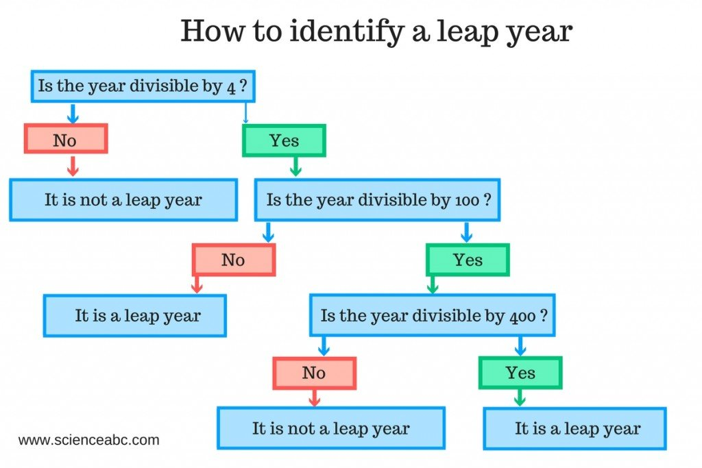

```python
year = 2100

check_leap = ((year % 4 == 0) and (year % 100 != 0)) or (year % 400 == 0)

check_leap
```

```
False
```

**Bonus Problem**: Given three numbers a, b, and c. You need to find which is the greatest of them all.

```python
a, b, c = 1,2,3

if a>b and a>c:
  print("a is biggest")
elif b>a and b>c:
  print("b is biggest")
else:
  print("c is biggest")
```

```
c is biggest
```

**Bonus Problem**: Given an integer n check if n is prime or not. A prime number is a number that is divisible by 1 and itself only.

**Note**: Print "True" if n is prime, otherwise print "False".

```python
n = 213

is_prime = True
for i in range(2, n):
  if n % i == 0:
    is_prime = False
    break

is_prime #Try 1 => Solve the issue
```

```
False
```

**Bonus Problem**: Given an integer n. Write a program to find the nth Fibonacci number.

F(0)= 0, F(1)=1

The nth Fibonacci number is given by the forumla F(n) = F(n-1) + F(n-2). The first few fibonacci numbers are: 0 1 1 2 3 5. . . .

```python
n = 3

a,b = 0,1
for _ in range(2, n+1):
  a,b = b,a+b

b
```

```
2
```

For more awesome problems: https://www.geeksforgeeks.org/python/python-conditional-statement-and-loops-coding-problems/

# Key Concepts Summary

| Topic | Key Point |
| --- | --- |
| **Variables** | Use `_`, avoid keywords |
| **Dynamic Typing** | Flexible, but risky |
| **Strings** | Immutable, slicing |
| **Lists** | Mutable, `+`, `append` |
| **Tuples** | Immutable, unpacking |
| **Dicts** | Key-value, mutable |
| **Loops** | `for` (sequences), `while` (condition) |
| **if** | Decision making |

# Home Assignment (Srinivisa Ramanunjan Formula)

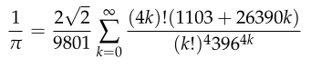

```python
import math

sum = 0

for k in range(100):
    num = math.factorial(4*k)*(1103+26390*k)
    dem = (math.factorial(k)**4)*(396**(4*k))
    sum += num/dem

pi_approx = 1 / (sum * 2*math.sqrt(2)/9801)
pi_approx
```

```
3.141592653589793
```